# nashwa atef week 2 final project

## DATA cleaning and preprocessing

```python
import pandas as pd
import numpy as np
import matplotlib.pyplot as plt
import seaborn as sns
```

## DATA PREPROCESSING

Data overview

```python
inventory = pd.read_csv("inventory.csv")
inventory
```

|  | Product Name | Year Month | Warehouse Inventory | Inventory Cost Per Unit |
| --- | --- | --- | --- | --- |
| 0 | Perfect Fitness Perfect Rip Deck | 201712 | 0 | 0.69517 |
| 1 | Nike Men's Dri-FIT Victory Golf Polo | 201712 | 2 | 1.29291 |
| 2 | O'Brien Men's Neoprene Life Vest | 201712 | 0 | 0.56531 |
| 3 | Nike Men's Free 5.0+ Running Shoe | 201712 | 1 | 1.26321 |
| 4 | Under Armour Girls' Toddler Spine Surge Runni | 201712 | 0 | 1.47648 |
| ... | ... | ... | ... | ... |
| 4195 | TaylorMade 2017 Purelite Stand Bag | 201501 | 0 | 1.44662 |
| 4196 | Ogio Race Golf Shoes | 201501 | 0 | 0.10310 |
| 4197 | GolfBuddy VT3 GPS Watch | 201501 | 0 | 1.77747 |
| 4198 | Titleist Small Wheeled Travel Cover | 201501 | 0 | 0.15244 |
| 4199 | Polar Loop Activity Tracker | 201501 | 1 | 0.88259 |

4200 rows × 4 columns

```python
inventory.shape
```

```
(4200, 4)
```

```python
fulfilment = pd.read_csv("fulfillment.csv")
fulfilment
```

|  | Product Name | Warehouse Order Fulfillment (days) |
| --- | --- | --- |
| 0 | Perfect Fitness Perfect Rip Deck | 8.3 |
| 1 | Nike Men's Dri-FIT Victory Golf Polo | 6.6 |
| 2 | O'Brien Men's Neoprene Life Vest | 5.5 |
| 3 | Nike Men's Free 5.0+ Running Shoe | 9.4 |
| 4 | Under Armour Girls' Toddler Spine Surge Runni | 6.3 |
| ... | ... | ... |
| 113 | Stiga Master Series ST3100 Competition Indoor | 4.7 |
| 114 | SOLE E35 Elliptical | 1.9 |
| 115 | Bushnell Pro X7 Jolt Slope Rangefinder | 2.0 |
| 116 | SOLE E25 Elliptical | 2.1 |
| 117 | Bowflex SelectTech 1090 Dumbbells | 7.7 |

118 rows × 2 columns

```python
fulfilment.shape
```

```
(118, 2)
```

```python
orders_shipment = pd.read_csv("orders_and_shipments.csv")
orders_shipment
```

|  | Order ID | Order Item ID | Order YearMonth | Order Year | Order Month | Order Day | Order Time | Order Quantity | Product Department | Product Category | ... | Customer Country | Warehouse Country | Shipment Year | Shipment Month | Shipment Day | Shipment Mode | Shipment Days - Scheduled | Gross Sales | Discount % | Profit |
| --- | --- | --- | --- | --- | --- | --- | --- | --- | --- | --- | --- | --- | --- | --- | --- | --- | --- | --- | --- | --- | --- |
| 0 | 3535 | 8793 | 201502 | 2015 | 2 | 21 | 14:07 | 1 | Fan Shop | Fishing | ... | Mexico | Puerto Rico | 2015 | 2 | 27 | Standard Class | 4 | 400 | 0.25 | 200 |
| 1 | 4133 | 10320 | 201503 | 2015 | 3 | 2 | 07:37 | 1 | Fan Shop | Fishing | ... | Brazil | Puerto Rico | 2015 | 3 | 6 | Standard Class | 4 | 400 | 0.09 | 200 |
| 2 | 7396 | 18517 | 201504 | 2015 | 4 | 18 | 22:47 | 1 | Fan Shop | Fishing | ... | Mexico | Puerto Rico | 2015 | 4 | 20 | Standard Class | 4 | 400 | 0.06 | 200 |
| 3 | 11026 | 27608 | 201506 | 2015 | 6 | 10 | 22:32 | 1 | Fan Shop | Fishing | ... | Denmark | Puerto Rico | 2015 | 6 | 12 | Standard Class | 4 | 400 | 0.15 | 200 |
| 4 | 11026 | 27609 | 201506 | 2015 | 6 | 10 | 22:32 | 1 | Fan Shop | Fishing | ... | Denmark | Puerto Rico | 2015 | 6 | 12 | Standard Class | 4 | 400 | 0.13 | 200 |
| ... | ... | ... | ... | ... | ... | ... | ... | ... | ... | ... | ... | ... | ... | ... | ... | ... | ... | ... | ... | ... | ... |
| 30866 | 73246 | 176561 | 201712 | 2017 | 12 | 5 | 04:59 | 1 | Fan Shop | Toys | ... | Australia | Puerto Rico | 2017 | 12 | 11 | Standard Class | 4 | 12 | 0.06 | 6 |
| 30867 | 7908 | 19762 | 201504 | 2015 | 4 | 26 | 10:10 | 1 | Fan Shop | Hunting & Shooting | ... | Paraguay | Puerto Rico | 2015 | 4 | 30 | Standard Class | 4 | 30 | 0.12 | 68 |
| 30868 | 29326 | 73368 | 201603 | 2016 | 3 | 4 | 01:51 | 1 | Fan Shop | Hunting & Shooting | ... | India | Puerto Rico | 2016 | 3 | 6 | Second Class | 2 | 30 | 0.09 | 68 |
| 30869 | 63308 | 158284 | 201707 | 2017 | 7 | 13 | 03:15 | 1 | Fan Shop | Hunting & Shooting | ... | Germany | Puerto Rico | 2017 | 7 | 17 | Second Class | 2 | 150 | 0.02 | 60 |
| 30870 | 67951 | 169874 | 201709 | 2017 | 9 | 18 | 21:54 | 1 | Fan Shop | Water Sports | ... | Italy | Puerto Rico | 2017 | 9 | 20 | First Class | 1 | 350 | - | 172 |

30871 rows × 24 columns

```python
orders_shipment.shape
```

```
(30871, 24)
```

### Data Cleaning

```python
inventory.info()
```

```
<class 'pandas.core.frame.DataFrame'>
RangeIndex: 4200 entries, 0 to 4199
Data columns (total 4 columns):
 #   Column                   Non-Null Count  Dtype
---  ------                   --------------  -----
 0   Product Name             4200 non-null   object
 1    Year Month              4200 non-null   int64
 2    Warehouse Inventory     4200 non-null   int64
 3   Inventory Cost Per Unit  4200 non-null   float64
dtypes: float64(1), int64(2), object(1)
memory usage: 131.4+ KB
```

```python
fulfilment.info()
```

```
<class 'pandas.core.frame.DataFrame'>
RangeIndex: 118 entries, 0 to 117
Data columns (total 2 columns):
 #   Column                                Non-Null Count  Dtype
---  ------                                --------------  -----
 0   Product Name                          118 non-null    object
 1    Warehouse Order Fulfillment (days)   118 non-null    float64
dtypes: float64(1), object(1)
memory usage: 2.0+ KB
```

```python
orders_shipment.info()
```

```
<class 'pandas.core.frame.DataFrame'>
RangeIndex: 30871 entries, 0 to 30870
Data columns (total 24 columns):
 #   Column                       Non-Null Count  Dtype
---  ------                       --------------  -----
 0   Order ID                     30871 non-null  int64
 1    Order Item ID               30871 non-null  int64
 2    Order YearMonth             30871 non-null  int64
 3    Order Year                  30871 non-null  int64
 4    Order Month                 30871 non-null  int64
 5    Order Day                   30871 non-null  int64
 6   Order Time                   30871 non-null  object
 7   Order Quantity               30871 non-null  int64
 8   Product Department           30871 non-null  object
 9   Product Category             30871 non-null  object
```

[output cut: 16 more lines]

The dataset provides three data tables including orde_shipment, inventory and fulfillment. After examining the data fields, I noticed that the dataset generally represents the following key information

Customer: General customers information about including identifiers and addresses

Order: order Information including order date , product and quantity ordered, order value

Shipment: Shipping information including shipping date, shipping mode

Product: Specific information about the ordered item including product name, product category, product department

Warehouse Inventory: Information on inventory management for each product name including monthly inventory, warehouse location, storage costs, order fulfillment

```python
#fix the column name by trimming the white space in the beginning and the end
inventory.columns=inventory.columns.str.strip()
fulfilment.columns=fulfilment.columns.str.strip()
orders_shipment.columns=orders_shipment.columns.str.strip()
```

```python
#chanaging the format of  the  columns names
inventory.columns=inventory.columns.str.lower()
inventory.columns =inventory.columns.str.replace(" ","_")
```

```python
fulfilment.columns=fulfilment.columns.str.lower()
fulfilment.columns =fulfilment.columns.str.replace(" ","_")
```

```python
#correct types off columns
inventory["year_month"]=inventory["year_month"].astype(str)
```

```python
orders_shipment[['Order Year','Order Month','Order Day','Shipment Year','Shipment Month','Shipment Day']] = orders_shipment[['Order Year','Order Month','Order Day','Shipment Year','Shipment Month','Shipment Day']].astype(str)
```

```python
orders_shipment["Discount %"] =orders_shipment["Discount %"].replace({'  -  ':"0"})
```

```python
orders_shipment["Discount %"]=orders_shipment['Discount %'].astype(float)
```

```python
orders_shipment["Gross Sales"]=orders_shipment["Gross Sales"].astype(float)
```

```python
#continue chaging names of column
orders_shipment.columns=orders_shipment.columns.str.lower()
orders_shipment.columns =orders_shipment.columns.str.replace(" ","_")
orders_shipment.columns
```

```
Index(['order_id', 'order_item_id', 'order_yearmonth', 'order_year',
       'order_month', 'order_day', 'order_time', 'order_quantity',
       'product_department', 'product_category', 'product_name', 'customer_id',
       'customer_market', 'customer_region', 'customer_country',
       'warehouse_country', 'shipment_year', 'shipment_month', 'shipment_day',
       'shipment_mode', 'shipment_days_-_scheduled', 'gross_sales',
       'discount_%', 'profit'],
      dtype='object')
```

```python
orders_shipment = orders_shipment.rename(columns={"shipment_days_-_scheduled" : "shipment_days_scheduled",'discount_%':'discount%'})
orders_shipment.columns
```

```
Index(['order_id', 'order_item_id', 'order_yearmonth', 'order_year',
       'order_month', 'order_day', 'order_time', 'order_quantity',
       'product_department', 'product_category', 'product_name', 'customer_id',
       'customer_market', 'customer_region', 'customer_country',
       'warehouse_country', 'shipment_year', 'shipment_month', 'shipment_day',
       'shipment_mode', 'shipment_days_scheduled', 'gross_sales', 'discount%',
       'profit'],
      dtype='object')
```

```python
orders_shipment = orders_shipment.rename(columns={'order_item_id':"product_id"})
orders_shipment.columns
```

```
Index(['order_id', 'product_id', 'order_yearmonth', 'order_year',
       'order_month', 'order_day', 'order_time', 'order_quantity',
       'product_department', 'product_category', 'product_name', 'customer_id',
       'customer_market', 'customer_region', 'customer_country',
       'warehouse_country', 'shipment_year', 'shipment_month', 'shipment_day',
       'shipment_mode', 'shipment_days_scheduled', 'gross_sales', 'discount%',
       'profit'],
      dtype='object')
```

We have some unecessary columns in the dataset

```python
#drop unecessary columns
orders_shipment = orders_shipment.drop(['order_time','order_yearmonth'] ,axis=1)
orders_shipment.columns
```

```
Index(['order_id', 'product_id', 'order_year', 'order_month', 'order_day',
       'order_quantity', 'product_department', 'product_category',
       'product_name', 'customer_id', 'customer_market', 'customer_region',
       'customer_country', 'warehouse_country', 'shipment_year',
       'shipment_month', 'shipment_day', 'shipment_mode',
       'shipment_days_scheduled', 'gross_sales', 'discount%', 'profit'],
      dtype='object')
```

The column customer_country contains some special characters.

```python
orders_shipment["customer_country"].unique()
```

```
array(['Mexico', 'Brazil', 'Denmark', 'Netherlands', 'Germany', 'China',
       'Indonesia', 'Pakistan', 'India', 'USA', 'Hungary', 'Sudan',
       'Democratic Republic of Congo', 'Poland', 'Togo', 'Guatemala',
       'Panama', 'Chile', 'France', 'Sweden', 'Dominican�Republic',
       'Venezuela', 'South Korea', 'Madagascar', 'Iran', 'Cuba',
       'Nicaragua', 'United Kingdom', 'Afghanistan', 'Singapore',
       'Morocco', 'Spain', 'Niger', 'Turkey', 'South Africa', 'Iraq',
       'Honduras', 'Italy', 'Australia', 'Cote d�Ivoire', 'Croatia',
       'Ecuador', 'Syria', 'Haiti', 'Bangladesh', 'Argentina', 'Romania',
       'El Salvador', 'Vietnam', 'Japan', 'Nigeria', 'Belarus',
       'Uzbekistan', 'Egypt', 'Albania', 'Georgia', 'Cameroon',
       'Colombia', 'New zealand', 'Canada', 'Thailand', 'Senegal',
       'Russia', 'Per�', 'Algeria�', 'Ukraine', 'Belgium', 'Philippines',
       'Austria', 'Uruguay', 'Malaysia', 'Hong Kong', 'Saudi Arabia',
       'Switzerland', 'Ireland', 'Bulgaria', 'Zambia', 'Jamaica', 'Ghana',
       'Yemen', 'Norway', 'Tanzania', 'Kazakhstan', 'Libya',
       'Trinidad and Tobago', 'Finland', 'Portugal', 'Kenya', 'Jordania',
       'Bolivia', 'Gabon', 'Angola', 'Myanmar', 'Mali', 'UAE',
       'Bosnia and Herzegovina', 'Guinea', 'Cambodia', 'Papua New Guinea',
       'Rwanda', 'Israel�', 'Guyana', 'Somalia', 'Barbados', 'Guadalupe',
       'Kyrgyzstan', 'Ben�n', 'Tunisia', 'Lithuania', 'Montenegro',
       'Costa Rica', 'Mozambique', 'Sri Lanka', 'Taiwan',
       'Czech Republic (Czechia)', 'Lesotho', 'Mongolia', 'Macedonia',
       'Zimbabwe', 'Liberia', 'Liban', 'Guinea-Bissau', 'Estonia',
       'Azerbaijan', 'Moldova', 'Republic of Congo', 'Gambia',
       'Mauritania', 'Belize', 'Qatar', 'Sierra Leona', 'Slovakia',
       'Martinique', 'Uganda', 'Namibia', 'Paraguay', 'Oman',
       'French Guiana', 'Nepal'], dtype=object)
```

```python
##replace the special characters in the Customer Country column
orders_shipment["customer_country"]= orders_shipment["customer_country"].replace({ 'Dominican�Republic': 'Dominican Republic',
    'Cote d�Ivoire': 'Cote d Ivoire', 'Per�': 'Peru','Algeria�': 'Algeria','Israel�':'Israel','Ben�n': 'Benin'})
orders_shipment["customer_country"].unique()
```

```
array(['Mexico', 'Brazil', 'Denmark', 'Netherlands', 'Germany', 'China',
       'Indonesia', 'Pakistan', 'India', 'USA', 'Hungary', 'Sudan',
       'Democratic Republic of Congo', 'Poland', 'Togo', 'Guatemala',
       'Panama', 'Chile', 'France', 'Sweden', 'Dominican Republic',
       'Venezuela', 'South Korea', 'Madagascar', 'Iran', 'Cuba',
       'Nicaragua', 'United Kingdom', 'Afghanistan', 'Singapore',
       'Morocco', 'Spain', 'Niger', 'Turkey', 'South Africa', 'Iraq',
       'Honduras', 'Italy', 'Australia', 'Cote d Ivoire', 'Croatia',
       'Ecuador', 'Syria', 'Haiti', 'Bangladesh', 'Argentina', 'Romania',
       'El Salvador', 'Vietnam', 'Japan', 'Nigeria', 'Belarus',
       'Uzbekistan', 'Egypt', 'Albania', 'Georgia', 'Cameroon',
       'Colombia', 'New zealand', 'Canada', 'Thailand', 'Senegal',
       'Russia', 'Peru', 'Algeria', 'Ukraine', 'Belgium', 'Philippines',
       'Austria', 'Uruguay', 'Malaysia', 'Hong Kong', 'Saudi Arabia',
       'Switzerland', 'Ireland', 'Bulgaria', 'Zambia', 'Jamaica', 'Ghana',
       'Yemen', 'Norway', 'Tanzania', 'Kazakhstan', 'Libya',
       'Trinidad and Tobago', 'Finland', 'Portugal', 'Kenya', 'Jordania',
       'Bolivia', 'Gabon', 'Angola', 'Myanmar', 'Mali', 'UAE',
       'Bosnia and Herzegovina', 'Guinea', 'Cambodia', 'Papua New Guinea',
       'Rwanda', 'Israel', 'Guyana', 'Somalia', 'Barbados', 'Guadalupe',
       'Kyrgyzstan', 'Benin', 'Tunisia', 'Lithuania', 'Montenegro',
       'Costa Rica', 'Mozambique', 'Sri Lanka', 'Taiwan',
       'Czech Republic (Czechia)', 'Lesotho', 'Mongolia', 'Macedonia',
       'Zimbabwe', 'Liberia', 'Liban', 'Guinea-Bissau', 'Estonia',
       'Azerbaijan', 'Moldova', 'Republic of Congo', 'Gambia',
       'Mauritania', 'Belize', 'Qatar', 'Sierra Leona', 'Slovakia',
       'Martinique', 'Uganda', 'Namibia', 'Paraguay', 'Oman',
       'French Guiana', 'Nepal'], dtype=object)
```

```python
#fix date format
orders_shipment['order_year_month'] = (
    orders_shipment['order_year'].astype(str).str.zfill(2) + '-' +
    orders_shipment['order_month'].astype(str).str.zfill(2)
)
orders_shipment['order_year_month']
```

```
0        2015-02
1        2015-03
2        2015-04
3        2015-06
4        2015-06
          ...
30866    2017-12
30867    2015-04
30868    2016-03
30869    2017-07
30870    2017-09
Name: order_year_month, Length: 30871, dtype: object
```

```python
orders_shipment['order_date'] = (
    orders_shipment['order_year'].astype(str).str.zfill(2) + '-' +
    orders_shipment['order_month'].astype(str).str.zfill(2) + '-' +
    orders_shipment['order_day'].astype(str).str.zfill(2)
)
orders_shipment['order_date']
```

```
0        2015-02-21
1        2015-03-02
2        2015-04-18
3        2015-06-10
4        2015-06-10
            ...
30866    2017-12-05
30867    2015-04-26
30868    2016-03-04
30869    2017-07-13
30870    2017-09-18
Name: order_date, Length: 30871, dtype: object
```

```python
orders_shipment['shipment_date'] = (
    orders_shipment['shipment_year'].astype(str).str.zfill(2) + '-' +
    orders_shipment['shipment_month'].astype(str).str.zfill(2) + '-' +
    orders_shipment['shipment_day'].astype(str).str.zfill(2)
)
orders_shipment['shipment_date']
```

```
0        2015-02-27
1        2015-03-06
2        2015-04-20
3        2015-06-12
4        2015-06-12
            ...
30866    2017-12-11
30867    2015-04-30
30868    2016-03-06
30869    2017-07-17
30870    2017-09-20
Name: shipment_date, Length: 30871, dtype: object
```

```python
inventory['year_month'] = pd.to_datetime(inventory['year_month'], format ="%Y%m")
inventory['year'] = inventory['year_month'].dt.year
inventory['month'] = inventory['year_month'].dt.month
inventory['year_month'] = inventory['year'].astype(str) + '-' + inventory['month'].astype(str).str.zfill(2)
inventory['year_month']
```

```
0       2017-12
1       2017-12
2       2017-12
3       2017-12
4       2017-12
         ...
4195    2015-01
4196    2015-01
4197    2015-01
4198    2015-01
4199    2015-01
Name: year_month, Length: 4200, dtype: object
```

Checking for missing value

```python
orders_shipment_missing_count = orders_shipment.isnull().sum()
orders_shipment_missing_count
```

```
order_id                   0
product_id                 0
order_year                 0
order_month                0
order_day                  0
order_quantity             0
product_department         0
product_category           0
product_name               0
customer_id                0
customer_market            0
customer_region            0
customer_country           0
warehouse_country          0
shipment_year              0
shipment_month             0
shipment_day               0
shipment_mode              0
shipment_days_scheduled    0
gross_sales                0
discount%                  0
profit                     0
order_year_month           0
order_date                 0
shipment_date              0
dtype: int64
```

```python
inventory_missing_count = inventory.isnull().sum()
inventory_missing_count
```

```
product_name               0
year_month                 0
warehouse_inventory        0
inventory_cost_per_unit    0
year                       0
month                      0
dtype: int64
```

```python
fulfillment_missing_count = fulfilment.isnull().sum()
fulfillment_missing_count
```

```
product_name                          0
warehouse_order_fulfillment_(days)    0
dtype: int64
```

There are no missing value in all three tables. This dataset seems to have already been clean

Checking for duplicates

```python
duplicate_rows = orders_shipment[orders_shipment.duplicated()]
```

```python
duplicate_rows = inventory[inventory.duplicated()]
```

```python
duplicate_rows = fulfilment[fulfilment.duplicated()]
```

Checking for which product category and product department the product name belongs to

```python
product_info = orders_shipment[['product_id','product_name', 'product_category', 'product_department']]
product = product_info.drop_duplicates("product_name")
product
```

|  | product_id | product_name | product_category | product_department |
| --- | --- | --- | --- | --- |
| 0 | 8793 | Field & Stream Sportsman 16 Gun Fire Safe | Fishing | Fan Shop |
| 157 | 2422 | Pelican Sunstream 100 Kayak | Water Sports | Fan Shop |
| 294 | 6944 | Diamondback Women's Serene Classic Comfort Bi | Camping & Hiking | Fan Shop |
| 418 | 5317 | O'Brien Men's Neoprene Life Vest | Indoor/Outdoor Games | Fan Shop |
| 463 | 6937 | Team Golf Texas Longhorns Putter Grip | Accessories | Outdoors |
| ... | ... | ... | ... | ... |
| 15458 | 178583 | First aid kit | Health and Beauty | Health and Beauty |
| 15464 | 178706 | Rock music | Music | Discs Shop |
| 15621 | 178650 | Men's gala suit | Men's Clothing | Apparel |
| 18869 | 176553 | Toys | Toys | Fan Shop |
| 28138 | 169985 | GoPro HERO3+ Black Edition Camera | Strength Training | Footwear |

113 rows × 4 columns

```python
product
```

|  | product_id | product_name | product_category | product_department |
| --- | --- | --- | --- | --- |
| 0 | 8793 | Field & Stream Sportsman 16 Gun Fire Safe | Fishing | Fan Shop |
| 157 | 2422 | Pelican Sunstream 100 Kayak | Water Sports | Fan Shop |
| 294 | 6944 | Diamondback Women's Serene Classic Comfort Bi | Camping & Hiking | Fan Shop |
| 418 | 5317 | O'Brien Men's Neoprene Life Vest | Indoor/Outdoor Games | Fan Shop |
| 463 | 6937 | Team Golf Texas Longhorns Putter Grip | Accessories | Outdoors |
| ... | ... | ... | ... | ... |
| 15458 | 178583 | First aid kit | Health and Beauty | Health and Beauty |
| 15464 | 178706 | Rock music | Music | Discs Shop |
| 15621 | 178650 | Men's gala suit | Men's Clothing | Apparel |
| 18869 | 176553 | Toys | Toys | Fan Shop |
| 28138 | 169985 | GoPro HERO3+ Black Edition Camera | Strength Training | Footwear |

113 rows × 4 columns

```python
dv=product.drop(columns=["product_category","product_department"])
dv["product_id"]=dv["product_id"].astype("object")
dv
```

|  | product_id | product_name |
| --- | --- | --- |
| 0 | 8793 | Field & Stream Sportsman 16 Gun Fire Safe |
| 157 | 2422 | Pelican Sunstream 100 Kayak |
| 294 | 6944 | Diamondback Women's Serene Classic Comfort Bi |
| 418 | 5317 | O'Brien Men's Neoprene Life Vest |
| 463 | 6937 | Team Golf Texas Longhorns Putter Grip |
| ... | ... | ... |
| 15458 | 178583 | First aid kit |
| 15464 | 178706 | Rock music |
| 15621 | 178650 | Men's gala suit |
| 18869 | 176553 | Toys |
| 28138 | 169985 | GoPro HERO3+ Black Edition Camera |

113 rows × 2 columns

```python
df=product
df["product_id"]=dv["product_id"].astype("object")
df
```

|  | product_id | product_name | product_category | product_department |
| --- | --- | --- | --- | --- |
| 0 | 8793 | Field & Stream Sportsman 16 Gun Fire Safe | Fishing | Fan Shop |
| 157 | 2422 | Pelican Sunstream 100 Kayak | Water Sports | Fan Shop |
| 294 | 6944 | Diamondback Women's Serene Classic Comfort Bi | Camping & Hiking | Fan Shop |
| 418 | 5317 | O'Brien Men's Neoprene Life Vest | Indoor/Outdoor Games | Fan Shop |
| 463 | 6937 | Team Golf Texas Longhorns Putter Grip | Accessories | Outdoors |
| ... | ... | ... | ... | ... |
| 15458 | 178583 | First aid kit | Health and Beauty | Health and Beauty |
| 15464 | 178706 | Rock music | Music | Discs Shop |
| 15621 | 178650 | Men's gala suit | Men's Clothing | Apparel |
| 18869 | 176553 | Toys | Toys | Fan Shop |
| 28138 | 169985 | GoPro HERO3+ Black Edition Camera | Strength Training | Footwear |

113 rows × 4 columns

```python
fulfilment=pd.merge(fulfilment,df, on="product_name", how="left")# creating a FK  in fulfilment
fulfilment
```

|  | product_name | warehouse_order_fulfillment_(days) | product_id | product_category | product_department |
| --- | --- | --- | --- | --- | --- |
| 0 | Perfect Fitness Perfect Rip Deck | 8.3 | 28332 | Cleats | Apparel |
| 1 | Nike Men's Dri-FIT Victory Golf Polo | 6.6 | 15255 | Women's Apparel | Golf |
| 2 | O'Brien Men's Neoprene Life Vest | 5.5 | 5317 | Indoor/Outdoor Games | Fan Shop |
| 3 | Nike Men's Free 5.0+ Running Shoe | 9.4 | 13821 | Cardio Equipment | Footwear |
| 4 | Under Armour Girls' Toddler Spine Surge Runni | 6.3 | 52736 | Shop By Sport | Golf |
| ... | ... | ... | ... | ... | ... |
| 113 | Stiga Master Series ST3100 Competition Indoor | 4.7 | 169789 | Hockey | Fitness |
| 114 | SOLE E35 Elliptical | 1.9 | NaN | NaN | NaN |
| 115 | Bushnell Pro X7 Jolt Slope Rangefinder | 2.0 | NaN | NaN | NaN |
| 116 | SOLE E25 Elliptical | 2.1 | NaN | NaN | NaN |
| 117 | Bowflex SelectTech 1090 Dumbbells | 7.7 | NaN | NaN | NaN |

118 rows × 5 columns

```python
df=pd.merge(inventory,product, on="product_name", how="left")# creating a FK  in inventory
df
```

|  | product_name | year_month | warehouse_inventory | inventory_cost_per_unit | year | month | product_id | product_category | product_department |
| --- | --- | --- | --- | --- | --- | --- | --- | --- | --- |
| 0 | Perfect Fitness Perfect Rip Deck | 2017-12 | 0 | 0.69517 | 2017 | 12 | 28332 | Cleats | Apparel |
| 1 | Nike Men's Dri-FIT Victory Golf Polo | 2017-12 | 2 | 1.29291 | 2017 | 12 | 15255 | Women's Apparel | Golf |
| 2 | O'Brien Men's Neoprene Life Vest | 2017-12 | 0 | 0.56531 | 2017 | 12 | 5317 | Indoor/Outdoor Games | Fan Shop |
| 3 | Nike Men's Free 5.0+ Running Shoe | 2017-12 | 1 | 1.26321 | 2017 | 12 | 13821 | Cardio Equipment | Footwear |
| 4 | Under Armour Girls' Toddler Spine Surge Runni | 2017-12 | 0 | 1.47648 | 2017 | 12 | 52736 | Shop By Sport | Golf |
| ... | ... | ... | ... | ... | ... | ... | ... | ... | ... |
| 4195 | TaylorMade 2017 Purelite Stand Bag | 2015-01 | 0 | 1.44662 | 2015 | 1 | 149770 | Golf Gloves | Outdoors |
| 4196 | Ogio Race Golf Shoes | 2015-01 | 0 | 0.10310 | 2015 | 1 | 163861 | Golf Bags & Carts | Outdoors |
| 4197 | GolfBuddy VT3 GPS Watch | 2015-01 | 0 | 1.77747 | 2015 | 1 | 153155 | Kids' Golf Clubs | Outdoors |
| 4198 | Titleist Small Wheeled Travel Cover | 2015-01 | 0 | 0.15244 | 2015 | 1 | 159034 | Golf Gloves | Outdoors |
| 4199 | Polar Loop Activity Tracker | 2015-01 | 1 | 0.88259 | 2015 | 1 | 153513 | Kids' Golf Clubs | Outdoors |

4200 rows × 9 columns

```python
df.isnull().sum()
```

```
product_name                 0
year_month                   0
warehouse_inventory          0
inventory_cost_per_unit      0
year                         0
month                        0
product_id                 175
product_category           175
product_department         175
dtype: int64
```

```python
null = df[(df["product_id"].isnull())  |(df["product_id"].isnull())]
null
```

|  | product_name | year_month | warehouse_inventory | inventory_cost_per_unit | year | month | product_id | product_category | product_department |
| --- | --- | --- | --- | --- | --- | --- | --- | --- | --- |
| 56 | Dell Laptop | 2017-12 | 14 | 1.56369 | 2017 | 12 | NaN | NaN | NaN |
| 114 | SOLE E35 Elliptical | 2017-12 | 1 | 0.36106 | 2017 | 12 | NaN | NaN | NaN |
| 115 | Bushnell Pro X7 Jolt Slope Rangefinder | 2017-12 | 9 | 2.22684 | 2017 | 12 | NaN | NaN | NaN |
| 116 | SOLE E25 Elliptical | 2017-12 | 23 | 1.84297 | 2017 | 12 | NaN | NaN | NaN |
| 117 | Bowflex SelectTech 1090 Dumbbells | 2017-12 | 36 | 1.49431 | 2017 | 12 | NaN | NaN | NaN |
| ... | ... | ... | ... | ... | ... | ... | ... | ... | ... |
| 4068 | Dell Laptop | 2015-02 | 37 | 2.16324 | 2015 | 2 | NaN | NaN | NaN |
| 4126 | SOLE E35 Elliptical | 2015-02 | 3 | 1.85317 | 2015 | 2 | NaN | NaN | NaN |
| 4127 | Bushnell Pro X7 Jolt Slope Rangefinder | 2015-02 | 35 | 1.22691 | 2015 | 2 | NaN | NaN | NaN |
| 4128 | SOLE E25 Elliptical | 2015-02 | 18 | 1.07032 | 2015 | 2 | NaN | NaN | NaN |
| 4129 | Bowflex SelectTech 1090 Dumbbells | 2015-02 | 35 | 1.65338 | 2015 | 2 | NaN | NaN | NaN |

175 rows × 9 columns

There are 5 product names that appear in the *inventory* table but not in the *order* table. This means that these are items that are in the company's inventory but have not been ordered by the customer. So it's impossible to determine which product category and product department those product names belong to

After investigating carefully, I decided to keep these product names as they account for a considerable amount of storage cost

```python
df['product_id'].fillna('None', inplace=True)
df['product_category'].fillna('None', inplace=True)
df['product_department'].fillna('None', inplace=True)
df[df['product_department'].isna()]
```

|  | product_name | year_month | warehouse_inventory | inventory_cost_per_unit | year | month | product_id | product_category | product_department |
| --- | --- | --- | --- | --- | --- | --- | --- | --- | --- |

```python
inventory = df
```

```python
inventory.info()
```

```
<class 'pandas.core.frame.DataFrame'>
RangeIndex: 4200 entries, 0 to 4199
Data columns (total 9 columns):
 #   Column                   Non-Null Count  Dtype
---  ------                   --------------  -----
 0   product_name             4200 non-null   object
 1   year_month               4200 non-null   object
 2   warehouse_inventory      4200 non-null   int64
 3   inventory_cost_per_unit  4200 non-null   float64
 4   year                     4200 non-null   int32
 5   month                    4200 non-null   int32
 6   product_id               4200 non-null   object
 7   product_category         4200 non-null   object
 8   product_department       4200 non-null   object
dtypes: float64(1), int32(2), int64(1), object(5)
memory usage: 262.6+ KB
```

```python
product.to_csv('product.csv' ,index_label= False)
```

```python
inventory.to_csv("cleaned inventory.csv")
```

```python
fulfilment.to_csv("cleaned_fulfilment.csv")
```

```python
orders_shipment.to_csv("cleaned_orders_shipment.csv")
```

```python
orders_shipment[["profit","gross_sales",'order_quantity','discount%']].describe()
```

|  | profit | gross_sales | order_quantity | discount% |
| --- | --- | --- | --- | --- |
| count | 30871.000000 | 30871.000000 | 30871.000000 | 30871.000000 |
| mean | 129.383305 | 200.235690 | 2.149817 | 0.101296 |
| std | 52.649857 | 114.251482 | 1.461393 | 0.070423 |
| min | 6.000000 | 10.000000 | 1.000000 | 0.000000 |
| 25% | 97.000000 | 120.000000 | 1.000000 | 0.040000 |
| 50% | 125.000000 | 200.000000 | 1.000000 | 0.090000 |
| 75% | 150.000000 | 300.000000 | 3.000000 | 0.160000 |
| max | 258.000000 | 533.000000 | 5.000000 | 0.250000 |

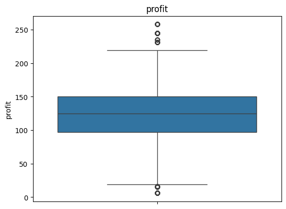

```python
sns.boxplot(y='profit', data=orders_shipment)
plt.title('profit')
```

```python
Q1 = orders_shipment["profit"].quantile(0.25)
Q3 = orders_shipment["profit"].quantile(0.75)
IQR = Q3 - Q1

# identify outliers
threshold = 1.5
outliers = orders_shipment[(orders_shipment["profit"] < Q1 - threshold * IQR) | (orders_shipment["profit"] > Q3 + threshold * IQR)]
```

```python
outliers["profit"].unique()
```

```
array([ 16, 245, 235, 258,  15,   6, 231])
```

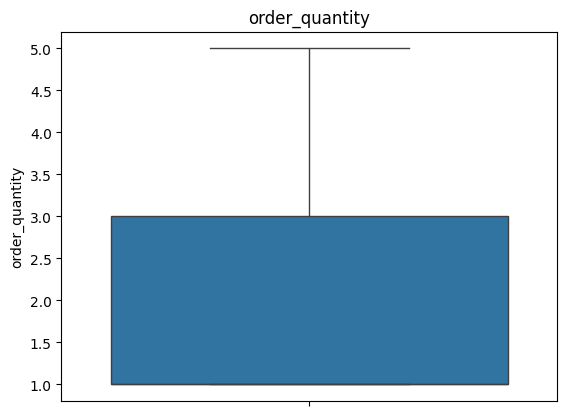

```python
sns.boxplot(y='order_quantity', data=orders_shipment)
plt.title('order_quantity')
```

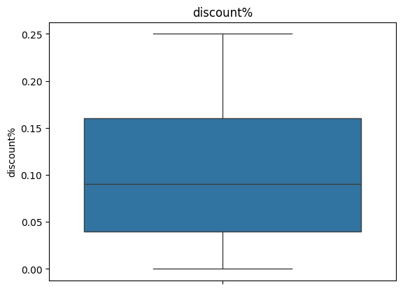

```python
sns.boxplot(y='discount%', data=orders_shipment)
plt.title('discount%')
```

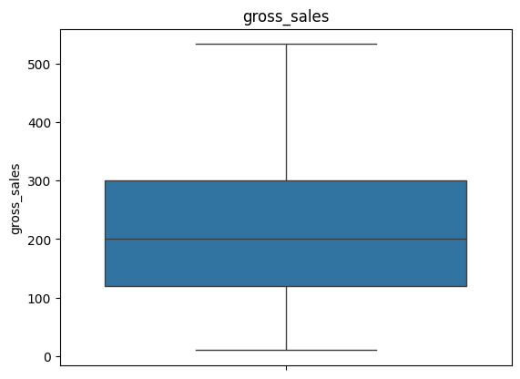

```python
sns.boxplot(y='gross_sales', data=orders_shipment)
plt.title('gross_sales')
```

Create business performance feature

```python
#Create net sales and unit price feature
orders_shipment['net_sales'] = orders_shipment['gross_sales'] - orders_shipment['gross_sales'] * orders_shipment['discount%']
orders_shipment['unit_price'] = orders_shipment['gross_sales'] / orders_shipment['order_quantity']
orders_shipment
```

|  | order_id | product_id | order_year | order_month | order_day | order_quantity | product_department | product_category | product_name | customer_id | ... | shipment_mode | shipment_days_scheduled | gross_sales | discount% | profit | order_year_month | order_date | shipment_date | net_sales | unit_price |
| --- | --- | --- | --- | --- | --- | --- | --- | --- | --- | --- | --- | --- | --- | --- | --- | --- | --- | --- | --- | --- | --- |
| 0 | 3535 | 8793 | 2015 | 2 | 21 | 1 | Fan Shop | Fishing | Field & Stream Sportsman 16 Gun Fire Safe | 7840 | ... | Standard Class | 4 | 400.0 | 0.25 | 200 | 2015-02 | 2015-02-21 | 2015-02-27 | 300.00 | 400.0 |
| 1 | 4133 | 10320 | 2015 | 3 | 2 | 1 | Fan Shop | Fishing | Field & Stream Sportsman 16 Gun Fire Safe | 1203 | ... | Standard Class | 4 | 400.0 | 0.09 | 200 | 2015-03 | 2015-03-02 | 2015-03-06 | 364.00 | 400.0 |
| 2 | 7396 | 18517 | 2015 | 4 | 18 | 1 | Fan Shop | Fishing | Field & Stream Sportsman 16 Gun Fire Safe | 10866 | ... | Standard Class | 4 | 400.0 | 0.06 | 200 | 2015-04 | 2015-04-18 | 2015-04-20 | 376.00 | 400.0 |
| 3 | 11026 | 27608 | 2015 | 6 | 10 | 1 | Fan Shop | Fishing | Field & Stream Sportsman 16 Gun Fire Safe | 3576 | ... | Standard Class | 4 | 400.0 | 0.15 | 200 | 2015-06 | 2015-06-10 | 2015-06-12 | 340.00 | 400.0 |
| 4 | 11026 | 27609 | 2015 | 6 | 10 | 1 | Fan Shop | Fishing | Field & Stream Sportsman 16 Gun Fire Safe | 3576 | ... | Standard Class | 4 | 400.0 | 0.13 | 200 | 2015-06 | 2015-06-10 | 2015-06-12 | 348.00 | 400.0 |
| ... | ... | ... | ... | ... | ... | ... | ... | ... | ... | ... | ... | ... | ... | ... | ... | ... | ... | ... | ... | ... | ... |
| 30866 | 73246 | 176561 | 2017 | 12 | 5 | 1 | Fan Shop | Toys | Toys | 16799 | ... | Standard Class | 4 | 12.0 | 0.06 | 6 | 2017-12 | 2017-12-05 | 2017-12-11 | 11.28 | 12.0 |
| 30867 | 7908 | 19762 | 2015 | 4 | 26 | 1 | Fan Shop | Hunting & Shooting | ENO Atlas Hammock Straps | 11950 | ... | Standard Class | 4 | 30.0 | 0.12 | 68 | 2015-04 | 2015-04-26 | 2015-04-30 | 26.40 | 30.0 |
| 30868 | 29326 | 73368 | 2016 | 3 | 4 | 1 | Fan Shop | Hunting & Shooting | ENO Atlas Hammock Straps | 8161 | ... | Second Class | 2 | 30.0 | 0.09 | 68 | 2016-03 | 2016-03-04 | 2016-03-06 | 27.30 | 30.0 |
| 30869 | 63308 | 158284 | 2017 | 7 | 13 | 1 | Fan Shop | Hunting & Shooting | insta-bed Neverflat Air Mattress | 5733 | ... | Second Class | 2 | 150.0 | 0.02 | 60 | 2017-07 | 2017-07-13 | 2017-07-17 | 147.00 | 150.0 |
| 30870 | 67951 | 169874 | 2017 | 9 | 18 | 1 | Fan Shop | Water Sports | Pelican Maverick 100X Kayak | 5030 | ... | First Class | 1 | 350.0 | 0.00 | 172 | 2017-09 | 2017-09-18 | 2017-09-20 | 350.00 | 350.0 |

30871 rows × 27 columns

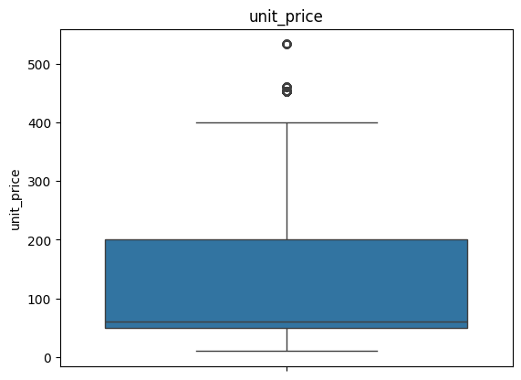

```python
sns.boxplot(y='unit_price', data= orders_shipment)
plt.title('unit_price')
```

```python
orders_shipment[(orders_shipment["unit_price"] > 400)]
orders_shipment
```

|  | order_id | product_id | order_year | order_month | order_day | order_quantity | product_department | product_category | product_name | customer_id | ... | shipment_mode | shipment_days_scheduled | gross_sales | discount% | profit | order_year_month | order_date | shipment_date | net_sales | unit_price |
| --- | --- | --- | --- | --- | --- | --- | --- | --- | --- | --- | --- | --- | --- | --- | --- | --- | --- | --- | --- | --- | --- |
| 0 | 3535 | 8793 | 2015 | 2 | 21 | 1 | Fan Shop | Fishing | Field & Stream Sportsman 16 Gun Fire Safe | 7840 | ... | Standard Class | 4 | 400.0 | 0.25 | 200 | 2015-02 | 2015-02-21 | 2015-02-27 | 300.00 | 400.0 |
| 1 | 4133 | 10320 | 2015 | 3 | 2 | 1 | Fan Shop | Fishing | Field & Stream Sportsman 16 Gun Fire Safe | 1203 | ... | Standard Class | 4 | 400.0 | 0.09 | 200 | 2015-03 | 2015-03-02 | 2015-03-06 | 364.00 | 400.0 |
| 2 | 7396 | 18517 | 2015 | 4 | 18 | 1 | Fan Shop | Fishing | Field & Stream Sportsman 16 Gun Fire Safe | 10866 | ... | Standard Class | 4 | 400.0 | 0.06 | 200 | 2015-04 | 2015-04-18 | 2015-04-20 | 376.00 | 400.0 |
| 3 | 11026 | 27608 | 2015 | 6 | 10 | 1 | Fan Shop | Fishing | Field & Stream Sportsman 16 Gun Fire Safe | 3576 | ... | Standard Class | 4 | 400.0 | 0.15 | 200 | 2015-06 | 2015-06-10 | 2015-06-12 | 340.00 | 400.0 |
| 4 | 11026 | 27609 | 2015 | 6 | 10 | 1 | Fan Shop | Fishing | Field & Stream Sportsman 16 Gun Fire Safe | 3576 | ... | Standard Class | 4 | 400.0 | 0.13 | 200 | 2015-06 | 2015-06-10 | 2015-06-12 | 348.00 | 400.0 |
| ... | ... | ... | ... | ... | ... | ... | ... | ... | ... | ... | ... | ... | ... | ... | ... | ... | ... | ... | ... | ... | ... |
| 30866 | 73246 | 176561 | 2017 | 12 | 5 | 1 | Fan Shop | Toys | Toys | 16799 | ... | Standard Class | 4 | 12.0 | 0.06 | 6 | 2017-12 | 2017-12-05 | 2017-12-11 | 11.28 | 12.0 |
| 30867 | 7908 | 19762 | 2015 | 4 | 26 | 1 | Fan Shop | Hunting & Shooting | ENO Atlas Hammock Straps | 11950 | ... | Standard Class | 4 | 30.0 | 0.12 | 68 | 2015-04 | 2015-04-26 | 2015-04-30 | 26.40 | 30.0 |
| 30868 | 29326 | 73368 | 2016 | 3 | 4 | 1 | Fan Shop | Hunting & Shooting | ENO Atlas Hammock Straps | 8161 | ... | Second Class | 2 | 30.0 | 0.09 | 68 | 2016-03 | 2016-03-04 | 2016-03-06 | 27.30 | 30.0 |
| 30869 | 63308 | 158284 | 2017 | 7 | 13 | 1 | Fan Shop | Hunting & Shooting | insta-bed Neverflat Air Mattress | 5733 | ... | Second Class | 2 | 150.0 | 0.02 | 60 | 2017-07 | 2017-07-13 | 2017-07-17 | 147.00 | 150.0 |
| 30870 | 67951 | 169874 | 2017 | 9 | 18 | 1 | Fan Shop | Water Sports | Pelican Maverick 100X Kayak | 5030 | ... | First Class | 1 | 350.0 | 0.00 | 172 | 2017-09 | 2017-09-18 | 2017-09-20 | 350.00 | 350.0 |

30871 rows × 27 columns

```python
#Create storage cost feature
inventory['storage_cost'] = inventory['inventory_cost_per_unit']*inventory['warehouse_inventory']
inventory
```

|  | product_name | year_month | warehouse_inventory | inventory_cost_per_unit | year | month | product_id | product_category | product_department | storage_cost |
| --- | --- | --- | --- | --- | --- | --- | --- | --- | --- | --- |
| 0 | Perfect Fitness Perfect Rip Deck | 2017-12 | 0 | 0.69517 | 2017 | 12 | 28332 | Cleats | Apparel | 0.00000 |
| 1 | Nike Men's Dri-FIT Victory Golf Polo | 2017-12 | 2 | 1.29291 | 2017 | 12 | 15255 | Women's Apparel | Golf | 2.58582 |
| 2 | O'Brien Men's Neoprene Life Vest | 2017-12 | 0 | 0.56531 | 2017 | 12 | 5317 | Indoor/Outdoor Games | Fan Shop | 0.00000 |
| 3 | Nike Men's Free 5.0+ Running Shoe | 2017-12 | 1 | 1.26321 | 2017 | 12 | 13821 | Cardio Equipment | Footwear | 1.26321 |
| 4 | Under Armour Girls' Toddler Spine Surge Runni | 2017-12 | 0 | 1.47648 | 2017 | 12 | 52736 | Shop By Sport | Golf | 0.00000 |
| ... | ... | ... | ... | ... | ... | ... | ... | ... | ... | ... |
| 4195 | TaylorMade 2017 Purelite Stand Bag | 2015-01 | 0 | 1.44662 | 2015 | 1 | 149770 | Golf Gloves | Outdoors | 0.00000 |
| 4196 | Ogio Race Golf Shoes | 2015-01 | 0 | 0.10310 | 2015 | 1 | 163861 | Golf Bags & Carts | Outdoors | 0.00000 |
| 4197 | GolfBuddy VT3 GPS Watch | 2015-01 | 0 | 1.77747 | 2015 | 1 | 153155 | Kids' Golf Clubs | Outdoors | 0.00000 |
| 4198 | Titleist Small Wheeled Travel Cover | 2015-01 | 0 | 0.15244 | 2015 | 1 | 159034 | Golf Gloves | Outdoors | 0.00000 |
| 4199 | Polar Loop Activity Tracker | 2015-01 | 1 | 0.88259 | 2015 | 1 | 153513 | Kids' Golf Clubs | Outdoors | 0.88259 |

4200 rows × 10 columns

```python
#Create shipping time feature
orders_shipment['shipping_time'] = pd.to_datetime(orders_shipment['shipment_date']) - pd.to_datetime(orders_shipment['order_date'])
orders_shipment['shipping_time'] = orders_shipment['shipping_time'].dt.days

#Create delay shipment feature
def calculate_delay(row):
    if row['shipping_time'] > row["shipment_days_scheduled"]:
        return 'Late'
    else:
        return 'On time'

orders_shipment['delay_Shipment'] = orders_shipment.apply(calculate_delay, axis=1)
orders_shipment
```

|  | order_id | product_id | order_year | order_month | order_day | order_quantity | product_department | product_category | product_name | customer_id | ... | gross_sales | discount% | profit | order_year_month | order_date | shipment_date | net_sales | unit_price | shipping_time | delay_Shipment |
| --- | --- | --- | --- | --- | --- | --- | --- | --- | --- | --- | --- | --- | --- | --- | --- | --- | --- | --- | --- | --- | --- |
| 0 | 3535 | 8793 | 2015 | 2 | 21 | 1 | Fan Shop | Fishing | Field & Stream Sportsman 16 Gun Fire Safe | 7840 | ... | 400.0 | 0.25 | 200 | 2015-02 | 2015-02-21 | 2015-02-27 | 300.00 | 400.0 | 6 | Late |
| 1 | 4133 | 10320 | 2015 | 3 | 2 | 1 | Fan Shop | Fishing | Field & Stream Sportsman 16 Gun Fire Safe | 1203 | ... | 400.0 | 0.09 | 200 | 2015-03 | 2015-03-02 | 2015-03-06 | 364.00 | 400.0 | 4 | On time |
| 2 | 7396 | 18517 | 2015 | 4 | 18 | 1 | Fan Shop | Fishing | Field & Stream Sportsman 16 Gun Fire Safe | 10866 | ... | 400.0 | 0.06 | 200 | 2015-04 | 2015-04-18 | 2015-04-20 | 376.00 | 400.0 | 2 | On time |
| 3 | 11026 | 27608 | 2015 | 6 | 10 | 1 | Fan Shop | Fishing | Field & Stream Sportsman 16 Gun Fire Safe | 3576 | ... | 400.0 | 0.15 | 200 | 2015-06 | 2015-06-10 | 2015-06-12 | 340.00 | 400.0 | 2 | On time |
| 4 | 11026 | 27609 | 2015 | 6 | 10 | 1 | Fan Shop | Fishing | Field & Stream Sportsman 16 Gun Fire Safe | 3576 | ... | 400.0 | 0.13 | 200 | 2015-06 | 2015-06-10 | 2015-06-12 | 348.00 | 400.0 | 2 | On time |
| ... | ... | ... | ... | ... | ... | ... | ... | ... | ... | ... | ... | ... | ... | ... | ... | ... | ... | ... | ... | ... | ... |
| 30866 | 73246 | 176561 | 2017 | 12 | 5 | 1 | Fan Shop | Toys | Toys | 16799 | ... | 12.0 | 0.06 | 6 | 2017-12 | 2017-12-05 | 2017-12-11 | 11.28 | 12.0 | 6 | Late |
| 30867 | 7908 | 19762 | 2015 | 4 | 26 | 1 | Fan Shop | Hunting & Shooting | ENO Atlas Hammock Straps | 11950 | ... | 30.0 | 0.12 | 68 | 2015-04 | 2015-04-26 | 2015-04-30 | 26.40 | 30.0 | 4 | On time |
| 30868 | 29326 | 73368 | 2016 | 3 | 4 | 1 | Fan Shop | Hunting & Shooting | ENO Atlas Hammock Straps | 8161 | ... | 30.0 | 0.09 | 68 | 2016-03 | 2016-03-04 | 2016-03-06 | 27.30 | 30.0 | 2 | On time |
| 30869 | 63308 | 158284 | 2017 | 7 | 13 | 1 | Fan Shop | Hunting & Shooting | insta-bed Neverflat Air Mattress | 5733 | ... | 150.0 | 0.02 | 60 | 2017-07 | 2017-07-13 | 2017-07-17 | 147.00 | 150.0 | 4 | Late |
| 30870 | 67951 | 169874 | 2017 | 9 | 18 | 1 | Fan Shop | Water Sports | Pelican Maverick 100X Kayak | 5030 | ... | 350.0 | 0.00 | 172 | 2017-09 | 2017-09-18 | 2017-09-20 | 350.00 | 350.0 | 2 | Late |

30871 rows × 29 columns

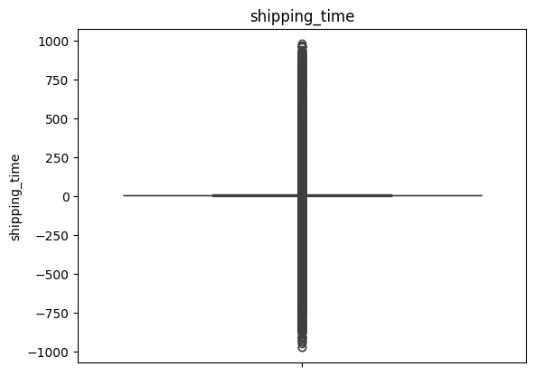

```python
#Drawing a boxplot of Unit Price
sns.boxplot(y='shipping_time', data= orders_shipment)
plt.title('shipping_time')
```

The Shipping column has some negative values. Thís is due to the error in recording since the Shipment Date < Order Date. There are also unusually large values

```python
#drop the abnormal Shipping Time
orders_shipment = orders_shipment[(orders_shipment['shipping_time'] >= 0) & (orders_shipment['shipping_time'] <= 28)]
orders_shipment
```

|  | order_id | product_id | order_year | order_month | order_day | order_quantity | product_department | product_category | product_name | customer_id | ... | gross_sales | discount% | profit | order_year_month | order_date | shipment_date | net_sales | unit_price | shipping_time | delay_Shipment |
| --- | --- | --- | --- | --- | --- | --- | --- | --- | --- | --- | --- | --- | --- | --- | --- | --- | --- | --- | --- | --- | --- |
| 0 | 3535 | 8793 | 2015 | 2 | 21 | 1 | Fan Shop | Fishing | Field & Stream Sportsman 16 Gun Fire Safe | 7840 | ... | 400.0 | 0.25 | 200 | 2015-02 | 2015-02-21 | 2015-02-27 | 300.00 | 400.0 | 6 | Late |
| 1 | 4133 | 10320 | 2015 | 3 | 2 | 1 | Fan Shop | Fishing | Field & Stream Sportsman 16 Gun Fire Safe | 1203 | ... | 400.0 | 0.09 | 200 | 2015-03 | 2015-03-02 | 2015-03-06 | 364.00 | 400.0 | 4 | On time |
| 2 | 7396 | 18517 | 2015 | 4 | 18 | 1 | Fan Shop | Fishing | Field & Stream Sportsman 16 Gun Fire Safe | 10866 | ... | 400.0 | 0.06 | 200 | 2015-04 | 2015-04-18 | 2015-04-20 | 376.00 | 400.0 | 2 | On time |
| 3 | 11026 | 27608 | 2015 | 6 | 10 | 1 | Fan Shop | Fishing | Field & Stream Sportsman 16 Gun Fire Safe | 3576 | ... | 400.0 | 0.15 | 200 | 2015-06 | 2015-06-10 | 2015-06-12 | 340.00 | 400.0 | 2 | On time |
| 4 | 11026 | 27609 | 2015 | 6 | 10 | 1 | Fan Shop | Fishing | Field & Stream Sportsman 16 Gun Fire Safe | 3576 | ... | 400.0 | 0.13 | 200 | 2015-06 | 2015-06-10 | 2015-06-12 | 348.00 | 400.0 | 2 | On time |
| ... | ... | ... | ... | ... | ... | ... | ... | ... | ... | ... | ... | ... | ... | ... | ... | ... | ... | ... | ... | ... | ... |
| 30866 | 73246 | 176561 | 2017 | 12 | 5 | 1 | Fan Shop | Toys | Toys | 16799 | ... | 12.0 | 0.06 | 6 | 2017-12 | 2017-12-05 | 2017-12-11 | 11.28 | 12.0 | 6 | Late |
| 30867 | 7908 | 19762 | 2015 | 4 | 26 | 1 | Fan Shop | Hunting & Shooting | ENO Atlas Hammock Straps | 11950 | ... | 30.0 | 0.12 | 68 | 2015-04 | 2015-04-26 | 2015-04-30 | 26.40 | 30.0 | 4 | On time |
| 30868 | 29326 | 73368 | 2016 | 3 | 4 | 1 | Fan Shop | Hunting & Shooting | ENO Atlas Hammock Straps | 8161 | ... | 30.0 | 0.09 | 68 | 2016-03 | 2016-03-04 | 2016-03-06 | 27.30 | 30.0 | 2 | On time |
| 30869 | 63308 | 158284 | 2017 | 7 | 13 | 1 | Fan Shop | Hunting & Shooting | insta-bed Neverflat Air Mattress | 5733 | ... | 150.0 | 0.02 | 60 | 2017-07 | 2017-07-13 | 2017-07-17 | 147.00 | 150.0 | 4 | Late |
| 30870 | 67951 | 169874 | 2017 | 9 | 18 | 1 | Fan Shop | Water Sports | Pelican Maverick 100X Kayak | 5030 | ... | 350.0 | 0.00 | 172 | 2017-09 | 2017-09-18 | 2017-09-20 | 350.00 | 350.0 | 2 | Late |

25861 rows × 29 columns

## week 2

What are the total net sales, profit and profit?

```python
total_net_sales= orders_shipment["net_sales"].sum()
total_profit = orders_shipment["profit"].sum()
print("total_net sales :", total_net_sales)
print("total_profit :", total_profit)
```

```
total_net sales : 4604036.11
total_profit : 3266361
```

How do the net sales and profit change over time?

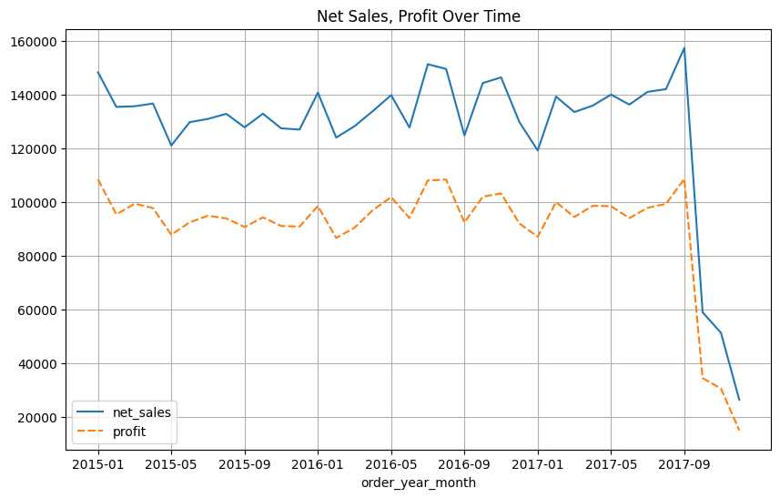

```python
net_sales = orders_shipment.groupby(["order_year_month"]).agg({'net_sales':'sum',
                                                'profit':'sum'})
fig, ax1 = plt.subplots(figsize=(10, 6))
ax = sns.lineplot(data = net_sales);
ax.set_xticks(ax.get_xticks()[::4])
plt.title('Net Sales, Profit Over Time')
plt.legend()
plt.grid(True)
```

What are the average net sales and profit per month?

```python
average_net_sales_profit = orders_shipment.groupby(["order_year_month"]).agg({'net_sales':'mean',
                                                'profit':'mean'})
average_net_sales_profit
```

| order_year_month | net_sales | profit |
| --- | --- | --- |
| 2015-01 | 174.553875 | 127.558304 |
| 2015-02 | 183.114980 | 128.971583 |
| 2015-03 | 172.263774 | 126.167726 |
| 2015-04 | 173.532541 | 124.096569 |
| 2015-05 | 174.785419 | 126.797688 |
| 2015-06 | 180.045042 | 128.256944 |
| 2015-07 | 172.183276 | 124.748684 |
| 2015-08 | 179.144953 | 126.585695 |
| 2015-09 | 175.200590 | 124.274348 |
| 2015-10 | 179.453689 | 127.277027 |
| 2015-11 | 176.617975 | 126.194175 |
| 2015-12 | 175.743199 | 125.713296 |
| 2016-01 | 175.803988 | 123.051250 |
| 2016-02 | 180.345429 | 125.975255 |
| 2016-03 | 179.224951 | 126.377622 |
| 2016-04 | 173.056714 | 125.360931 |
| 2016-05 | 172.064101 | 125.270936 |
| 2016-06 | 173.642272 | 127.790476 |
| 2016-07 | 181.086084 | 129.288623 |
| 2016-08 | 176.451499 | 127.819362 |
| 2016-09 | 172.227721 | 127.498619 |
| 2016-10 | 172.907302 | 122.189448 |
| 2016-11 | 181.303209 | 127.764560 |
| 2016-12 | 174.728464 | 123.839623 |
| 2017-01 | 171.381180 | 125.179856 |
| 2017-02 | 181.677089 | 130.377285 |
| 2017-03 | 171.706641 | 121.431145 |
| 2017-04 | 177.739228 | 128.913613 |
| 2017-05 | 183.615302 | 129.077428 |
| 2017-06 | 185.033533 | 127.623641 |
| 2017-07 | 185.931425 | 128.969657 |
| 2017-08 | 184.807005 | 129.180990 |
| 2017-09 | 193.246953 | 133.312039 |
| 2017-10 | 236.381044 | 137.871486 |
| 2017-11 | 210.745514 | 125.448560 |
| 2017-12 | 113.836710 | 64.683983 |

How do the number of orders change over time?

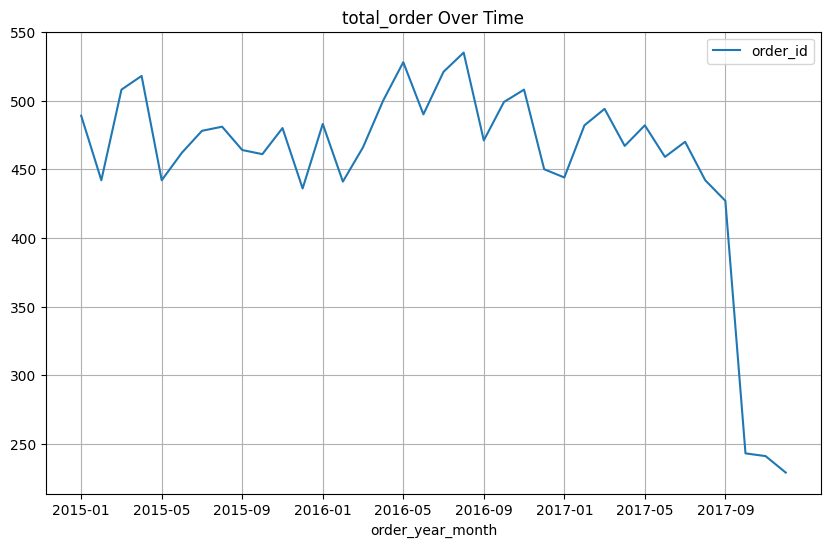

```python
total_order = orders_shipment.groupby(["order_year_month"]).agg({"order_id":"nunique"})
fig, ax1 = plt.subplots(figsize=(10, 6))
ax = sns.lineplot(data = total_order);
ax.set_xticks(ax.get_xticks()[::4])
plt.title('total_order Over Time')
plt.legend()
plt.grid(True)
```

How do the average order quantity and average unit price change over time?

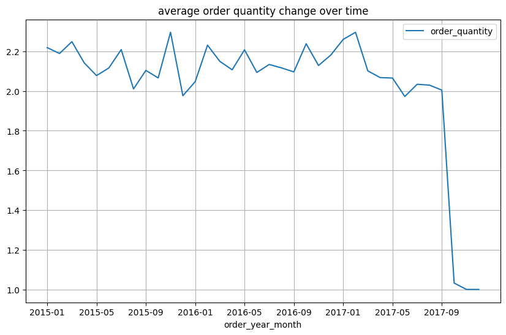

```python
total_order = orders_shipment.groupby(["order_year_month"]).agg({"order_quantity":"mean"})
fig, ax1 = plt.subplots(figsize=(10, 6))
ax = sns.lineplot(data = total_order);
ax.set_xticks(ax.get_xticks()[::4])
plt.title('average order quantity change over time')
plt.legend()
plt.grid(True)
```

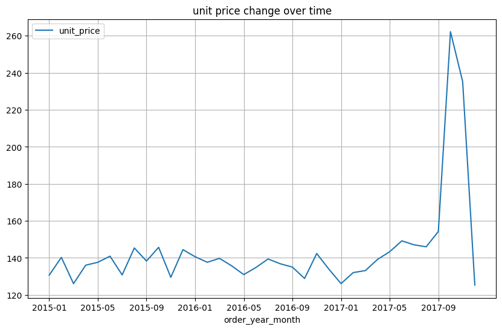

```python
total_order = orders_shipment.groupby(["order_year_month"]).agg({"unit_price":"mean"})
total_order
fig, ax1 = plt.subplots(figsize=(10, 6))
ax = sns.lineplot(data = total_order);
ax.set_xticks(ax.get_xticks()[::4])
plt.title('unit price change over time')
plt.legend()
plt.grid(True)
```

Which product departments account for the majority of net sales and number of orders?

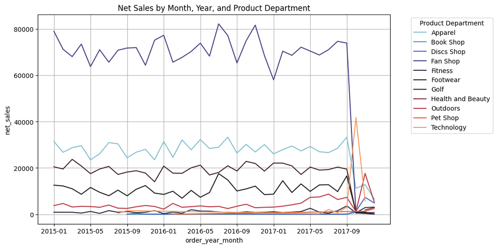

```python
product_sales  = orders_shipment.groupby(["product_department","order_year_month"]).agg({"net_sales":"sum"})
product_sales
fig, ax1 = plt.subplots(figsize=(10, 6))
ax = sns.lineplot(x='order_year_month',y = 'net_sales', data = product_sales, hue='product_department', palette='icefire');
ax.set_xticks(ax.get_xticks()[::4])
plt.title('Net Sales by Month, Year, and Product Department')
plt.legend(title = 'Product Department', bbox_to_anchor=(1.05, 1), loc='upper left')
plt.grid(True)
```

The product department that made the most contributions to net sales were golf, apparel, fanshop, and footwear. Revenue from these product department, however, suddenly fell and nearly vanished in Q4 2017. Product department such Discs Shop and Technology, meanwhile, shown room for expansion with rising net revenues.

[figure not shown]

```python
product_sales  = orders_shipment.groupby(["product_department","order_year_month"]).agg({"order_id":"nunique"})
fig, ax1 = plt.subplots(figsize=(10, 6))
ax = sns.lineplot(x='order_year_month',y = 'order_id', data = product_sales, hue='product_department', palette='icefire');
ax.set_xticks(ax.get_xticks()[::4])
plt.title('Net Sales by Month, Year, and Product Department')
plt.legend(title = 'Product Department', bbox_to_anchor=(1.05, 1), loc='upper left')
plt.grid(True)
```

The same trend also occurs when we count the number of orders for each product department over time

How was the distribution of customers by country and market?

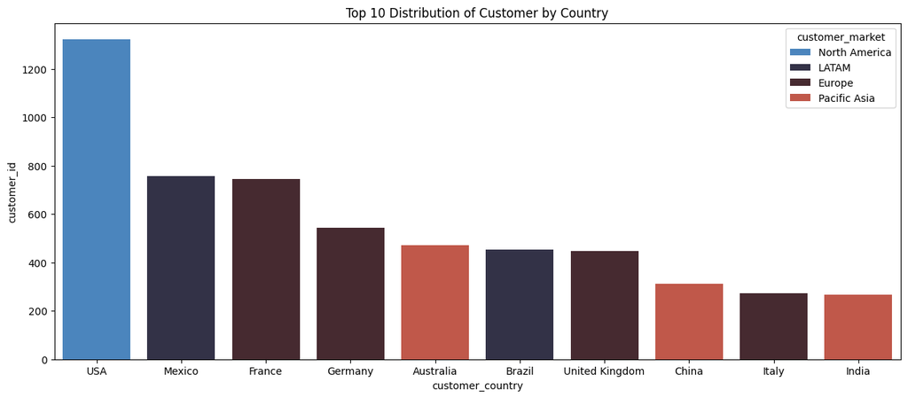

```python
product_sales  = orders_shipment.groupby(["customer_market","customer_country"]).agg({"customer_id":"nunique"}).sort_values(by="customer_id",ascending=False).head(10)
fig, ax1 = plt.subplots(figsize=(15, 6))
sns.barplot(data = product_sales, x= 'customer_country', y='customer_id',hue='customer_market', palette= 'icefire')
plt.title('Top 10 Distribution of Customer by Country')
plt.show()
```

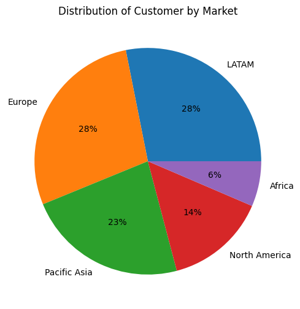

```python
product_sales  = orders_shipment.groupby(["customer_market"]).agg({"customer_id":"nunique"}).sort_values(by="customer_id",ascending=False).head(10)
fig, ax1 = plt.subplots(figsize=(15, 6))
labels= product_sales.index
plt.pie(product_sales["customer_id"] ,labels=labels,autopct='%.0f%%')
plt.title('Distribution of Customer by Market')
plt.show()
```

How many customers does the company have over time?

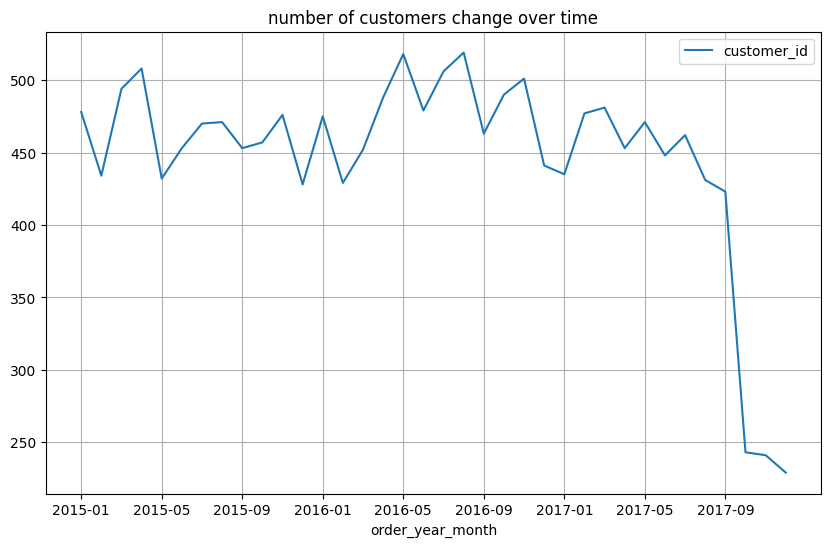

```python
total_customer = orders_shipment.groupby(["order_year_month"]).agg({"customer_id":"nunique"})
fig, ax1 = plt.subplots(figsize=(10, 6))
ax = sns.lineplot(data = total_customer);
ax.set_xticks(ax.get_xticks()[::4])
plt.title('number of customers change over time')
plt.legend()
plt.grid(True)
```

Which product categories and product names are most preferred?

[figure not shown]

```python
product_sales  = orders_shipment.groupby(["product_category","product_department"]).agg({"product_id":"nunique"}).sort_values(by="product_id",ascending=False)
fig, ax1 = plt.subplots(figsize=(15, 6))
sns.barplot(data = product_sales, x= 'product_category', y='product_id', palette= 'icefire' )
plt.xticks(rotation = 90)
plt.title('Distribution of product by Country')
plt.show()
```

```python
product_sales  = orders_shipment.groupby(["product_name"]).agg({"product_id":"nunique"}).sort_values(by="product_id",ascending=False).head(10)
product_sales
```

| product_name | product_id |
| --- | --- |
| Nike Men's CJ Elite 2 TD Football Cleat | 3368 |
| Perfect Fitness Perfect Rip Deck | 3328 |
| Nike Men's Dri-FIT Victory Golf Polo | 3058 |
| Field & Stream Sportsman 16 Gun Fire Safe | 2694 |
| O'Brien Men's Neoprene Life Vest | 2671 |
| Pelican Sunstream 100 Kayak | 2617 |
| Diamondback Women's Serene Classic Comfort Bi | 2044 |
| Under Armour Girls' Toddler Spine Surge Runni | 1735 |
| Nike Men's Free 5.0+ Running Shoe | 1256 |
| Web Camera | 121 |

Which product categories and product names are most profitable?

[figure not shown]

```python
product_sales  = orders_shipment.groupby(["product_category","product_department"]).agg({"profit":"sum"}).sort_values(by="profit",ascending=False)
fig, ax1 = plt.subplots(figsize=(15, 6))
sns.barplot(data = product_sales, x= 'product_category', y='profit', palette= 'icefire' )
plt.xticks(rotation = 90)
plt.title('Distribution of product by Country')
plt.show()
```

```python
product_sales  = orders_shipment.groupby(["product_name"]).agg({"profit":"sum"}).sort_values(by="profit",ascending=False).head(10)
product_sales
```

| product_name | profit |
| --- | --- |
| Field & Stream Sportsman 16 Gun Fire Safe | 538800 |
| Perfect Fitness Perfect Rip Deck | 489216 |
| Nike Men's Dri-FIT Victory Golf Polo | 382250 |
| O'Brien Men's Neoprene Life Vest | 333875 |
| Nike Men's Free 5.0+ Running Shoe | 307720 |
| Diamondback Women's Serene Classic Comfort Bi | 306600 |
| Pelican Sunstream 100 Kayak | 261700 |
| Nike Men's CJ Elite 2 TD Football Cleat | 218920 |
| Under Armour Girls' Toddler Spine Surge Runni | 168295 |
| Web Camera | 26499 |

It's no wonder that the best selling products are the most profitable

Which product departments account for the majority of warehouse inventory and storage cost?

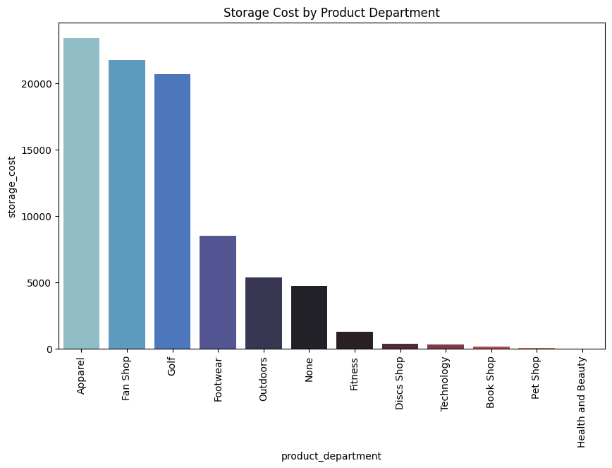

```python
inventory_cost  = inventory.groupby(["product_department"]).agg({"storage_cost":"sum"}).sort_values(by="storage_cost",ascending=False)
fig, ax1 = plt.subplots(figsize=(10, 6))
sns.barplot(data = inventory_cost, x= 'product_department', y='storage_cost', palette= 'icefire' )
plt.xticks(rotation = 90)
plt.title('Storage Cost by Product Department')
plt.show()
```

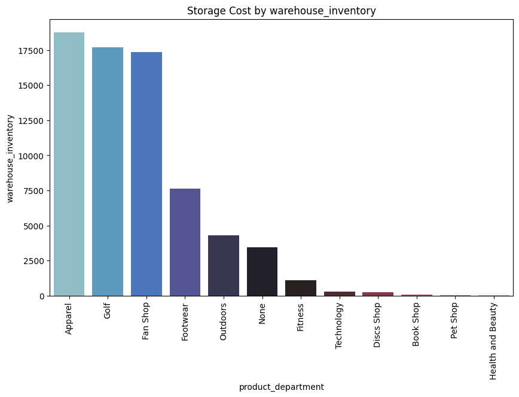

```python
inventory_cost  = inventory.groupby(["product_department"]).agg({"warehouse_inventory":"sum"}).sort_values(by="warehouse_inventory",ascending=False)
fig, ax1 = plt.subplots(figsize=(10, 6))
sns.barplot(data = inventory_cost, x= 'product_department', y='warehouse_inventory', palette= 'icefire' )
plt.xticks(rotation = 90)
plt.title('Storage Cost by warehouse_inventory')
plt.show()
```

How is the inventory cost per unit distributed by the product department?

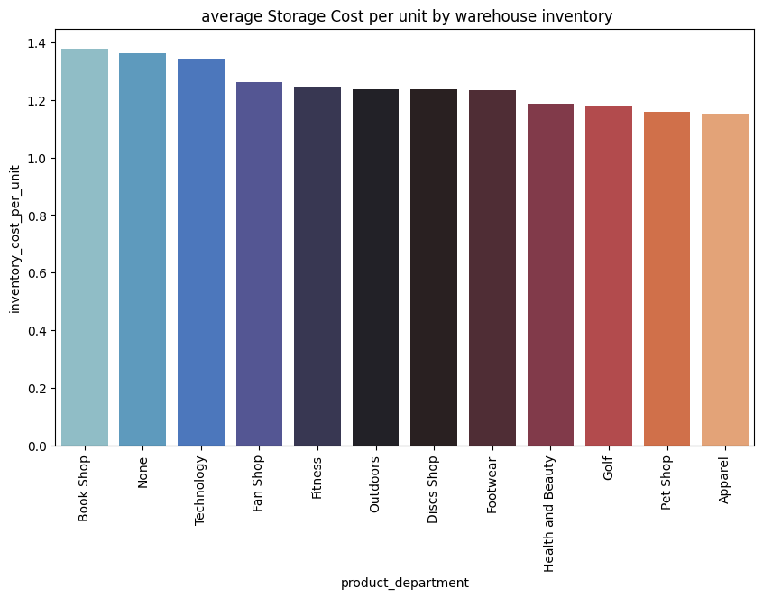

```python
inventory_cost  = inventory.groupby(["product_department"]).agg({"inventory_cost_per_unit":"mean"}).sort_values(by="inventory_cost_per_unit",ascending=False)
fig, ax1 = plt.subplots(figsize=(10, 6))
sns.barplot(data = inventory_cost, x= 'product_department', y='inventory_cost_per_unit', palette= 'icefire' )
plt.xticks(rotation = 90)
plt.title(' average Storage Cost per unit by warehouse inventory')
plt.show()
```

How do the warehouse inventory and storing costs change over time?

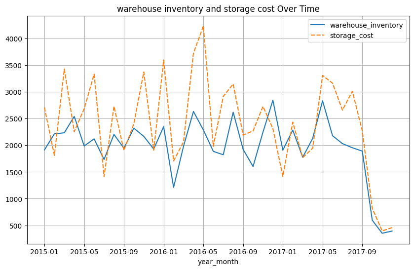

```python
inventory_cost = inventory.groupby(["year_month"]).agg({'warehouse_inventory':'sum',
                                                'storage_cost':'sum'})
fig, ax1 = plt.subplots(figsize=(10, 6))
ax = sns.lineplot(data = inventory_cost);
ax.set_xticks(ax.get_xticks()[::4])
plt.title('warehouse inventory and storage cost Over Time')
plt.legend()
plt.grid(True)
```

This demonstrates that inventory levels are a key factor influencing storage costs

Which product names and product departments account for the majority of storing cost

```python
inventory_cost  = inventory.groupby(["product_department","product_name"]).agg({"storage_cost":"mean"}).sort_values(by="storage_cost",ascending=False).head(20)
inventory_cost
```

| product_department | product_name | storage_cost |
| --- | --- | --- |
| Apparel | Perfect Fitness Perfect Rip Deck | 514.381016 |
| Golf | Nike Men's Dri-FIT Victory Golf Polo | 400.195984 |
| Fan Shop | O'Brien Men's Neoprene Life Vest | 333.049347 |
| Footwear | Nike Men's Free 5.0+ Running Shoe | 195.436517 |
| Golf | Under Armour Girls' Toddler Spine Surge Runni | 149.070165 |
| Apparel | Nike Men's CJ Elite 2 TD Football Cleat | 129.677183 |
| Fan Shop | Field & Stream Sportsman 16 Gun Fire Safe | 100.292524 |
|  | Pelican Sunstream 100 Kayak | 87.292014 |
|  | Diamondback Women's Serene Classic Comfort Bi | 76.159411 |
| None | Bowflex SelectTech 1090 Dumbbells | 34.837438 |
|  | Dell Laptop | 29.566755 |
|  | Bushnell Pro X7 Jolt Slope Rangefinder | 24.905275 |
|  | SOLE E25 Elliptical | 24.059074 |
|  | SOLE E35 Elliptical | 20.676289 |
| Outdoors | Glove It Women's Mod Oval 3-Zip Carry All Gol | 8.059257 |
| Fitness | adidas Men's F10 Messi TRX FG Soccer Cleat | 7.971239 |
| Outdoors | Titleist Pro V1x Golf Balls | 7.915577 |
| Technology | Web Camera | 7.660087 |
| Outdoors | Team Golf Pittsburgh Steelers Putter Grip | 7.616926 |
|  | Clicgear 8.0 Shoe Brush | 6.243453 |

What is the average of the average fulfillment order?

```python
avg_fulfillment_order = fulfilment["warehouse_order_fulfillment_(days)"].mean()
print("avg_fulfillment_order :",avg_fulfillment_order)
```

```
avg_fulfillment_order : 5.333898305084746
```

What is the average order fulfillment of each product department?

[figure not shown]

```python
inventory_cost  = fulfilment.groupby(["product_department"]).agg({"warehouse_order_fulfillment_(days)":"mean"}).sort_values(by="warehouse_order_fulfillment_(days)",ascending=False)
fig, ax1 = plt.subplots(figsize=(10, 6))
sns.barplot(data = inventory_cost, x= 'product_department', y='warehouse_order_fulfillment_(days)', palette= 'icefire' )
plt.xticks(rotation = 90)
plt.title(' average Storage Cost per unit by warehouse inventory')
plt.show()
```

Which warehouses are orders shipped from?

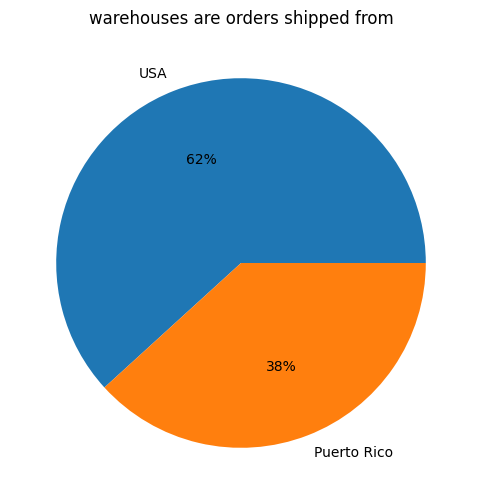

```python
shipment  = orders_shipment.groupby(["warehouse_country"]).agg({"order_id":"nunique"}).sort_values(by="order_id",ascending=False)
fig, ax1 = plt.subplots(figsize=(15, 6))
labels= shipment.index
plt.pie(shipment["order_id"] ,labels=labels,autopct='%.0f%%')
plt.title('warehouses are orders shipped from')
plt.show()
```

the order mainly shipped from USA

Which shipment modes are preferred by customers?

[figure not shown]

```python
Shipments = orders_shipment.groupby(["shipment_mode"]).agg({"order_id":"nunique"}).sort_values(by="order_id",ascending=False)
fig, ax1 = plt.subplots(figsize=(15, 6))
labels= Shipments.index
plt.pie(Shipments["order_id"] ,labels=labels,autopct='%.0f%%')
plt.title('warehouses are orders shipped from')
plt.show()
```

What is the shipping time for each shipment mode?

```python
Shipments =  orders_shipment.groupby(["shipment_mode","shipping_time"]).agg({"order_id":"nunique"}).sort_values(by="shipping_time",ascending=True)
Shipments = Shipments.pivot_table(index='shipping_time', columns='shipment_mode', values='order_id', aggfunc='first')
Shipments
```

| shipment_mode shipping_time | First Class | Same Day | Second Class | Standard Class |
| --- | --- | --- | --- | --- |
| 0 | 48.0 | 310.0 | 72.0 | 161.0 |
| 1 | 55.0 | 269.0 | 61.0 | 139.0 |
| 2 | 1484.0 | 139.0 | 940.0 | 2890.0 |
| 3 | 163.0 | 73.0 | 241.0 | 851.0 |
| 4 | 144.0 | 80.0 | 825.0 | 2507.0 |
| 5 | 175.0 | 92.0 | 221.0 | 824.0 |
| 6 | 160.0 | 76.0 | 535.0 | 1665.0 |
| 7 | 4.0 | 3.0 | 10.0 | 13.0 |
| 8 | 4.0 | 3.0 | 6.0 | 15.0 |
| 9 | 4.0 | 3.0 | 5.0 | 8.0 |
| 10 | 2.0 | 1.0 | 7.0 | 13.0 |
| 11 | 3.0 | NaN | 4.0 | 10.0 |
| 12 | 6.0 | 2.0 | 9.0 | 13.0 |
| 13 | 7.0 | NaN | 4.0 | 11.0 |
| 14 | 4.0 | 1.0 | 3.0 | 13.0 |
| 15 | 4.0 | NaN | 6.0 | 11.0 |
| 16 | 4.0 | 4.0 | 6.0 | 11.0 |
| 17 | 2.0 | 2.0 | 6.0 | 12.0 |
| 18 | 5.0 | 3.0 | 6.0 | 5.0 |
| 19 | 5.0 | 2.0 | 1.0 | 6.0 |
| 20 | 4.0 | NaN | 2.0 | 13.0 |
| 21 | 3.0 | 1.0 | 2.0 | 11.0 |
| 22 | 4.0 | NaN | 4.0 | 15.0 |
| 23 | NaN | 2.0 | 3.0 | 13.0 |
| 24 | 6.0 | NaN | 3.0 | 15.0 |
| 25 | 5.0 | 2.0 | 1.0 | 7.0 |
| 26 | 2.0 | NaN | 1.0 | 6.0 |
| 27 | 7.0 | 1.0 | 4.0 | 10.0 |
| 28 | 2.0 | 3.0 | 5.0 | 10.0 |

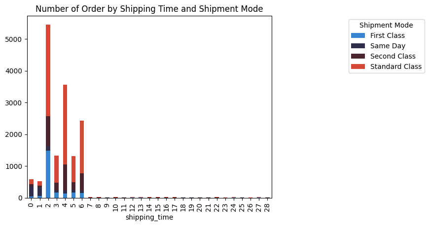

```python
Shipments.plot(kind='bar', stacked=True, title='Number of Order by Shipping Time and Shipment Mode', color = sns.color_palette('icefire', n_colors =4))
plt.legend(title = 'Shipment Mode', bbox_to_anchor=(1.3, 1), loc='upper left')
plt.show()
```

The company is having problems with the shipping time because there are quite a few orders that are selected for fast shipment mode such as same day and first class, but the items are shipped days later

What is the late shipment rate by product market?

```python
late = orders_shipment[orders_shipment['delay_Shipment'] == 'Late'].groupby('customer_market').size().reset_index(name='Late Orders')
total = orders_shipment.groupby('customer_market').size().reset_index(name='Total Orders')
late_order = pd.merge(late, total, on='customer_market')

#Calculate late shipment rate by product department
late_order['Late Shipment Rate'] = late_order['Late Orders']/late_order['Total Orders']
late_order
```

|  | customer_market | Late Orders | Total Orders | Late Shipment Rate |
| --- | --- | --- | --- | --- |
| 0 | Africa | 640 | 1661 | 0.385310 |
| 1 | Europe | 3145 | 7171 | 0.438572 |
| 2 | LATAM | 3357 | 7788 | 0.431048 |
| 3 | North America | 1708 | 3873 | 0.441002 |
| 4 | Pacific Asia | 2317 | 5368 | 0.431632 |